# DSM-050 Coursework Project - Understanding how working from home has affected employees and their attitudes surrounding it.

Student Number: 190556211

## 1. Research Topic and Background

### Introduction

The Covid-19 pandemic has had a huge impact globally, not just on health and wellness of individuals but also on the abiliy to function in our everyday lives. It has necessitated a huge shift in our behavior in order to remain safe and help prevent the further spread of the disease in our communities.

A major revelation over this period has been the forced working from home situation for most employees at companis that had previously frowned upon remote working due to the percieved loss of productivity that would come from employees not being situated in a physical office.

I set out to explore how people were working before the pandemic versus what their work situations look like now and their attitudes surrounding working from home.

### Motivation

As a millenial, I have also been drawn to the idea of having the freedom to structure my work days as I wish and the ability to live the lifestyle I choose anywhere in the world, while still being able to complete my work to a satisfactory standard. I had also longed for a working environment such as this but also felt shackled to the corporate idea of needing to be based within an office. This was forced upon me this year when my company closed and required all staff to work from home. I know many people who have been forced into a similiar situation and found that their working conditions and happiness changed drastically. It was clear that this would be an excellent area for a research survey project as companies gloablly are now considering a shift towards remote work as it helps to cut their costs and can increaser staff efficieny and happiness. The results of this survey will be of particular interest to both companies and to employees.

### Sample and Population

For the purpose of this study I chose took a sample of my Linkedin network and their connections, the sample was simply selected by those who took the time to fill in my survey as I requested in a Linkedin post. This sample would relate to the full population of Linkedin users who may or may not have seen a change in their working environment as a result of the forced shift to remote working as result of the Covid-19 pandemic.

### Research Question

Objective: Understand how working from home has affected employees and their attitudes surrounding it.

In order to achieve this objective, I came up with the following 3 research questions to which my survey questions would map to:

1. Are employees as efficient and productive while working from home as they would be in the office?
2. Are companies able to communicate effectively with their employees?
3. Are employees as happy working from home as they would be in the office?

Scope: A sample of at least 30 respondents from a population defined as my Linkedin network and their connections.

## 2. Survey design

When designing this survey I tried to keep the following survey design principles in mind:

1. Keeping the instructions as clear and concise as possible
2. Avoiding bias in the questions wording
3. Making the survey as simple as possible for the respondents to complete
4. Keep it short so as not to lose respondents attention span
5. Make the answers easy enough to analyse

I decided to use a mix of some open and some closed questions in order to gather the necessary information. I tried to limit the amount of open questions in order to reduce the complexities surrounding analysis of free-text entries. The answer choices have been mostly limited to a selection of answers. There are also some likert scale type questions that have been included which map to the main research questions designed above.

The structure of this survey is as follows:

- Demographic questions- Key demographics included in the survey are age, country of residence, industry etc
- Univariate style questions - these questions are used to gauge respondents opinions on the subject
- Likert scale questions - these map directly to the research questions which the survey aims to solve

For reference I have included a copy of the survey that respondents completed as a pdf document with the submission of this notebook.

From the outset I have also tried to be aware of how biases may arise from the study. One possible area for bias is in the sample of respondents from the overall population. This arises because the population of interest for this survey is the my network on Linkedin and because the sample has not been randomly selected to complete this survey but instead were asked to do it as a favour, there is room for bias because we only consider the answers of those who have taken the time to complete the survey. This is a major problem in all surveys and thus many survey researchers use some sort of incentive in order to entice potential respondents to complete their survey.

## 3. Analysis

### Initial Steps

In total I received 33 responses to my survey. The first step in order to analyse the results of the survey was to load the all the necessary packages and set a few notebook options in order to display the results better. I then loaded the output of the survey obtained as a CSV file into a dataframe.

```python
# Import all neccessary packages
import pandas as pd
import numpy as np
import matplotlib.pyplot as plt

from textwrap import wrap
import likert_plot

pd.set_option('display.max_columns', None)
%matplotlib inline
```

```python
# Look at raw survey data to see what cleaning needs to be done to convert into tidy data
df_raw = pd.read_csv('results-for-understanding-2020-12-15-0752.csv')
df_raw.head()
```

|  | Unique Response Number | 1. Which age category do you belong to? | 2. Where do you currently live? | 3. What industry do you work in? | 4. At what stage in your career are you? | 5. Do you have children? | 6. Are you currently working remotely? | 7. What was your companies stance on working remotely before the pandemic? | 8. What do you see as the biggest benefit of working remotely? | 9. What is the biggest issue you see with working remotely? | 10. Please rate how strongly you agree or disagree with the following statements: | 10.1.a. I could do my job just as effectively working from home. | 10.2.a. I am able to stick to a work schedule. | 10.3.a. I am expected to respond to emails/messages immediately. | 10.4.a. My company provides me with the tools and software necessary to make remote working possible. | 10.5.a. I get the enough support from my manager. | 10.6.a. I am able to connect with my manager as well as if I was in the office. | 10.7.a. I feel that I am able to easily reach my colleagues. | 10.8.a. I feel that my colleagues keep me in the loop. | 10.9.a. I am happy with how frequently I interact with colleagues. | 10.10.a. I feel that the remote working policy is clear. | 10.11.a. I know what is expected of me every day. | 10.12.a. My company communicates efficiently. | 10.13.a. I am happy with my work-life balance. | 10.14.a. I am happy with my ability to work from home. | 11. Would you like to work remotely going forward? |
| --- | --- | --- | --- | --- | --- | --- | --- | --- | --- | --- | --- | --- | --- | --- | --- | --- | --- | --- | --- | --- | --- | --- | --- | --- | --- | --- |
| 0 | 669016-669007-68725236 | 18-24 | South Africa | Software | Junior Level (2-5 years in the workforce) | No | Yes, due to COVID-19 restrictions but will ret... | Full time in the office | Flexibility | Loneliness | NaN | Agree | Agree | Agree | Agree | Agree | Agree | Agree | Disagree | Agree | Agree | Disagree | Neither agree nor disagree | Agree | Agree | Yes, part time |
| 1 | 669016-669007-68725674 | 18-24 | South Africa | Software | Entry level (less than 2 years in the workforce) | No | Yes, due to COVID-19 restrictions but will ret... | Everone works remotely | Flexibility | Distractions | NaN | Strongly agree | Strongly agree | Neither agree nor disagree | Strongly agree | Strongly agree | Agree | Neither agree nor disagree | Agree | Neither agree nor disagree | Strongly agree | Agree | Strongly agree | Strongly agree | Strongly agree | Yes, part time |
| 2 | 669016-669007-68725808 | 35-44 | South Africa | Finance and Insurance | Senior stage (more than 15 years in the workfo... | Yes | Yes, full time | Full time in the office | Time with family | Switching off after work | NaN | Strongly agree | Strongly agree | Neither agree nor disagree | Strongly agree | Strongly agree | Strongly agree | Strongly agree | Agree | Strongly agree | Strongly agree | Strongly agree | Strongly agree | Strongly agree | Strongly agree | Yes, full time |
| 3 | 669016-669007-68726565 | 18-24 | South Africa | Finance and Insurance | Junior Level (2-5 years in the workforce) | No | Yes, due to COVID-19 restrictions but will ret... | Full time in the office | Time with family | Staying motivated | NaN | Agree | Agree | Agree | Strongly agree | Strongly agree | Agree | Agree | Agree | Agree | Agree | Agree | Agree | Strongly agree | Strongly agree | Yes, full time |
| 4 | 669016-669007-68728541 | 25-34 | South Africa | Finance and Insurance | Junior Level (2-5 years in the workforce) | No | Yes, full time | I have the ability to work remotely as needed | Flexibility | Distractions | NaN | Strongly agree | Agree | Neither agree nor disagree | Strongly agree | Agree | Agree | Strongly agree | Agree | Strongly agree | Strongly agree | Strongly agree | Agree | Agree | Strongly agree | Yes, full time |

It is clear that the dataframe obtained above from a simple import of the survey results csv file is not going to be sufficient for the purpose of our analysis and thus I decided to create two seperate dataframes with one for the nominal data obtained and one for the ordinal data obtained. The majority of nominal data consists of demographic information, as well as some simple questions while the ordinal data is solely related to the likert scale type questions that were used in the survey.

```python
# Pull all nominal variables into a seperate dataframe
df_nominal = pd.read_csv('results-for-understanding-2020-12-15-0752.csv',
                 usecols=[0,1,2,3,4,5,6,7,8,9,25],
                 #index_col=0,
                 names=['id','age', 'location', 'industry', 'career_stage', 'children', 'current_wfh', 'pre_wfh', 'pros', 'cons', 'future_preference'],
                 skiprows=1)

df_nominal['id'] = df_nominal['id'].apply(lambda x: x.split('-')[2])
df_nominal = df_nominal.set_index('id')

# Set dtypes correctly for nominal data
df_nominal['age'] = df_nominal['age'].astype('category')
df_nominal['location'] = df_nominal['location'].astype('category')
df_nominal['industry'] = df_nominal['industry'].astype('category')
df_nominal['career_stage'] = df_nominal['career_stage'].astype('category')
df_nominal['children'] = df_nominal['children'].astype('category')
df_nominal['current_wfh'] = df_nominal['current_wfh'].astype('category')
df_nominal['pre_wfh'] = df_nominal['pre_wfh'].astype('category')
df_nominal['pros'] = df_nominal['pros'].astype('category')
df_nominal['cons'] = df_nominal['cons'].astype('category')
df_nominal['future_preference'] = df_nominal['future_preference'].astype('category')

df_nominal.head()
```

| id | age | location | industry | career_stage | children | current_wfh | pre_wfh | pros | cons | future_preference |
| --- | --- | --- | --- | --- | --- | --- | --- | --- | --- | --- |
| 68725236 | 18-24 | South Africa | Software | Junior Level (2-5 years in the workforce) | No | Yes, due to COVID-19 restrictions but will ret... | Full time in the office | Flexibility | Loneliness | Yes, part time |
| 68725674 | 18-24 | South Africa | Software | Entry level (less than 2 years in the workforce) | No | Yes, due to COVID-19 restrictions but will ret... | Everone works remotely | Flexibility | Distractions | Yes, part time |
| 68725808 | 35-44 | South Africa | Finance and Insurance | Senior stage (more than 15 years in the workfo... | Yes | Yes, full time | Full time in the office | Time with family | Switching off after work | Yes, full time |
| 68726565 | 18-24 | South Africa | Finance and Insurance | Junior Level (2-5 years in the workforce) | No | Yes, due to COVID-19 restrictions but will ret... | Full time in the office | Time with family | Staying motivated | Yes, full time |
| 68728541 | 25-34 | South Africa | Finance and Insurance | Junior Level (2-5 years in the workforce) | No | Yes, full time | I have the ability to work remotely as needed | Flexibility | Distractions | Yes, full time |

```python
# look at summary stats for nominal variables
df_nominal.describe()
```

|  | age | location | industry | career_stage | children | current_wfh | pre_wfh | pros | cons | future_preference |
| --- | --- | --- | --- | --- | --- | --- | --- | --- | --- | --- |
| count | 33 | 33 | 32 | 33 | 33 | 33 | 33 | 33 | 33 | 33 |
| unique | 5 | 6 | 12 | 5 | 2 | 4 | 4 | 5 | 5 | 3 |
| top | 25-34 | South Africa | Finance and Insurance | Junior Level (2-5 years in the workforce) | No | Yes, full time | Full time in the office | Flexibility | Switching off after work | Yes, part time |
| freq | 25 | 28 | 8 | 13 | 26 | 12 | 16 | 20 | 14 | 20 |

```python
# look at dtypes for nominal variables
df_nominal.dtypes
```

```
age                  category
location             category
industry             category
career_stage         category
children             category
current_wfh          category
pre_wfh              category
pros                 category
cons                 category
future_preference    category
dtype: object
```

```python
# Pull all ordinal variables into a seperate dataframe
df_ordinal = pd.read_csv('results-for-understanding-2020-12-15-0752.csv',
                 usecols=[0,11,12,13,14,15,16,17,18,19,20,21,22,23,24],
                 #index_col=0,
                 names=['id',
                        'I could do my job just as effectively working from home.',
                        'I am able to stick to a work schedule.',
                        'I am expected to respond to emails/messages immediately.',
                        'My company provides me with the tools and software necessary to make remote working possible.',
                        'I get the enough support from my manager.',
                        'I am able to connect with my manager as well as if I was in the office.',
                        'I feel that I am able to easily reach my colleagues.',
                        'I feel that my colleagues keep me in the loop.',
                        'I am happy with how frequently I interact with colleagues.',
                        'I feel that the remote working policy is clear.',
                        'I know what is expected of me every day.',
                        'My company communicates efficiently.',
                        'I am happy with my work-life balance.',
                        'I am happy with my ability to work from home.'],
                 skiprows=1)

df_ordinal['id'] = df_ordinal['id'].apply(lambda x: x.split('-')[2])
df_ordinal = df_ordinal.set_index('id')
```

```python
df_ordinal
```

| id | I could do my job just as effectively working from home. | I am able to stick to a work schedule. | I am expected to respond to emails/messages immediately. | My company provides me with the tools and software necessary to make remote working possible. | I get the enough support from my manager. | I am able to connect with my manager as well as if I was in the office. | I feel that I am able to easily reach my colleagues. | I feel that my colleagues keep me in the loop. | I am happy with how frequently I interact with colleagues. | I feel that the remote working policy is clear. | I know what is expected of me every day. | My company communicates efficiently. | I am happy with my work-life balance. | I am happy with my ability to work from home. |
| --- | --- | --- | --- | --- | --- | --- | --- | --- | --- | --- | --- | --- | --- | --- |
| 68725236 | Agree | Agree | Agree | Agree | Agree | Agree | Agree | Disagree | Agree | Agree | Disagree | Neither agree nor disagree | Agree | Agree |
| 68725674 | Strongly agree | Strongly agree | Neither agree nor disagree | Strongly agree | Strongly agree | Agree | Neither agree nor disagree | Agree | Neither agree nor disagree | Strongly agree | Agree | Strongly agree | Strongly agree | Strongly agree |
| 68725808 | Strongly agree | Strongly agree | Neither agree nor disagree | Strongly agree | Strongly agree | Strongly agree | Strongly agree | Agree | Strongly agree | Strongly agree | Strongly agree | Strongly agree | Strongly agree | Strongly agree |
| 68726565 | Agree | Agree | Agree | Strongly agree | Strongly agree | Agree | Agree | Agree | Agree | Agree | Agree | Agree | Strongly agree | Strongly agree |
| 68728541 | Strongly agree | Agree | Neither agree nor disagree | Strongly agree | Agree | Agree | Strongly agree | Agree | Strongly agree | Strongly agree | Strongly agree | Agree | Agree | Strongly agree |
| 68739605 | Agree | Agree | Neither agree nor disagree | Strongly agree | Agree | Agree | Agree | Agree | Neither agree nor disagree | Strongly agree | Agree | Agree | Strongly agree | Strongly agree |
| 68741704 | Agree | Strongly agree | Strongly disagree | Strongly agree | Agree | Agree | Strongly agree | Agree | Strongly agree | Strongly agree | Strongly agree | Strongly agree | Agree | Strongly agree |
| 68743393 | Agree | Disagree | Agree | Strongly agree | Agree | Neither agree nor disagree | Agree | Disagree | Disagree | Disagree | Disagree | Neither agree nor disagree | Disagree | Neither agree nor disagree |
| 68755463 | Strongly agree | Strongly agree | Agree | Strongly agree | Disagree | Agree | Disagree | Disagree | Agree | Strongly agree | Strongly agree | Strongly agree | Strongly agree | Strongly agree |
| 68763872 | Strongly agree | Strongly agree | Disagree | Agree | Disagree | Disagree | Agree | Neither agree nor disagree | Neither agree nor disagree | Agree | Agree | Disagree | Strongly agree | Strongly agree |
| 68774020 | Strongly agree | Strongly agree | Disagree | Strongly agree | Disagree | Neither agree nor disagree | Strongly agree | Disagree | Strongly agree | Strongly agree | Disagree | Disagree | Disagree | Strongly agree |
| 68777704 | Agree | Agree | Agree | Agree | Neither agree nor disagree | Agree | Agree | Agree | Agree | Neither agree nor disagree | Agree | Agree | Disagree | Agree |
| 68779285 | Strongly agree | Strongly agree | Agree | Strongly agree | Strongly agree | Disagree | Neither agree nor disagree | Neither agree nor disagree | Disagree | Strongly agree | Strongly agree | Strongly agree | Neither agree nor disagree | Strongly agree |
| 68784724 | Agree | Agree | Disagree | Disagree | Agree | Agree | Agree | Agree | Agree | Agree | Agree | Agree | Agree | Agree |
| 68784919 | Strongly agree | Strongly agree | Disagree | Strongly agree | Strongly agree | Disagree | Strongly agree | Strongly agree | Agree | Strongly agree | Strongly agree | Strongly agree | Agree | Strongly agree |
| 68785577 | Agree | Agree | Disagree | Disagree | Agree | Agree | Agree | Agree | Disagree | Agree | Agree | Agree | Disagree | Agree |
| 68789780 | Neither agree nor disagree | Strongly agree | Disagree | Agree | Agree | Disagree | Agree | Neither agree nor disagree | Strongly disagree | Neither agree nor disagree | Disagree | Strongly disagree | Disagree | Neither agree nor disagree |
| 68791932 | Strongly agree | Strongly agree | Disagree | Agree | Agree | Neither agree nor disagree | Agree | Agree | Agree | Agree | Strongly agree | Strongly agree | Strongly agree | Strongly agree |
| 68794888 | Neither agree nor disagree | Agree | Neither agree nor disagree | Disagree | Agree | Disagree | Disagree | Neither agree nor disagree | Disagree | Agree | Agree | Agree | Agree | Neither agree nor disagree |
| 68795242 | Strongly agree | Agree | Disagree | Agree | Strongly agree | Strongly agree | Agree | Neither agree nor disagree | Neither agree nor disagree | Strongly agree | Strongly agree | Agree | Agree | Strongly agree |
| 68799483 | Strongly agree | Agree | Agree | Strongly agree | Neither agree nor disagree | Disagree | Agree | Agree | Neither agree nor disagree | Agree | Agree | Agree | Agree | Agree |
| 68801335 | Strongly agree | Agree | Agree | Strongly agree | Agree | Agree | Agree | Neither agree nor disagree | Strongly agree | Agree | Strongly agree | Agree | Strongly agree | Strongly agree |
| 68801687 | Neither agree nor disagree | Strongly agree | Neither agree nor disagree | Neither agree nor disagree | Neither agree nor disagree | Neither agree nor disagree | Strongly agree | Strongly agree | Disagree | Neither agree nor disagree | Neither agree nor disagree | Agree | Strongly agree | Strongly agree |
| 68802161 | Agree | Agree | Agree | Agree | Agree | Disagree | Agree | Agree | Disagree | Agree | Agree | Agree | Disagree | Agree |
| 68803237 | Neither agree nor disagree | Agree | Agree | Strongly agree | Agree | Disagree | Agree | Disagree | Disagree | Neither agree nor disagree | Strongly agree | Agree | Agree | Agree |
| 68836149 | Disagree | Disagree | Agree | Agree | Agree | Disagree | Disagree | Disagree | Agree | Agree | Disagree | Disagree | Disagree | Disagree |
| 68858159 | Disagree | Agree | Agree | Agree | Agree | Agree | Agree | Agree | Disagree | Agree | Agree | Agree | Neither agree nor disagree | Agree |
| 68878513 | Strongly agree | Strongly agree | Disagree | Strongly agree | Neither agree nor disagree | Neither agree nor disagree | Agree | Strongly agree | Strongly agree | Agree | Strongly agree | Strongly agree | Agree | Agree |
| 68901046 | Strongly agree | Strongly agree | Neither agree nor disagree | Strongly agree | Agree | Disagree | Neither agree nor disagree | Neither agree nor disagree | Disagree | Agree | Agree | Agree | Neither agree nor disagree | Agree |
| 69202429 | Agree | Agree | Strongly agree | Strongly agree | Strongly agree | Agree | Agree | Agree | Agree | Agree | Agree | Agree | Agree | Agree |
| 69273874 | Strongly agree | Strongly agree | Strongly agree | Strongly agree | Strongly agree | Strongly agree | Strongly agree | Strongly agree | Strongly agree | Strongly agree | Strongly agree | Strongly agree | Neither agree nor disagree | Strongly agree |
| 69341837 | Strongly agree | Strongly agree | Strongly agree | Strongly agree | Neither agree nor disagree | Neither agree nor disagree | Agree | Agree | Agree | Agree | Agree | Agree | Disagree | Strongly agree |
| 69356932 | Agree | Strongly agree | Agree | Agree | Agree | Agree | Neither agree nor disagree | Neither agree nor disagree | Disagree | Neither agree nor disagree | Agree | Agree | Agree | Agree |

```python
# check nominal data summary stats
df_ordinal.describe()
```

|  | I could do my job just as effectively working from home. | I am able to stick to a work schedule. | I am expected to respond to emails/messages immediately. | My company provides me with the tools and software necessary to make remote working possible. | I get the enough support from my manager. | I am able to connect with my manager as well as if I was in the office. | I feel that I am able to easily reach my colleagues. | I feel that my colleagues keep me in the loop. | I am happy with how frequently I interact with colleagues. | I feel that the remote working policy is clear. | I know what is expected of me every day. | My company communicates efficiently. | I am happy with my work-life balance. | I am happy with my ability to work from home. |
| --- | --- | --- | --- | --- | --- | --- | --- | --- | --- | --- | --- | --- | --- | --- |
| count | 33 | 33 | 33 | 33 | 33 | 33 | 33 | 33 | 33 | 33 | 33 | 33 | 33 | 33 |
| unique | 4 | 3 | 5 | 4 | 4 | 4 | 4 | 4 | 5 | 4 | 4 | 5 | 4 | 4 |
| top | Strongly agree | Strongly agree | Agree | Strongly agree | Agree | Agree | Agree | Agree | Agree | Agree | Agree | Agree | Agree | Strongly agree |
| freq | 16 | 16 | 13 | 19 | 17 | 14 | 19 | 15 | 10 | 16 | 15 | 18 | 12 | 17 |

```python
#check nominal data types
df_nominal.dtypes
```

```
age                  category
location             category
industry             category
career_stage         category
children             category
current_wfh          category
pre_wfh              category
pros                 category
cons                 category
future_preference    category
dtype: object
```

### Exploratory Data Analysis

#### Demographic Data

In data analysis, quick and dirty plots are often used in order to gain a better understanding of the ditribution of the data and look for any patterns that may exist in the data. In this case I have plotted all of the demographic information using a horizontal bar chart and have also plottted some other survey questions using a standard bar chart. This helps to get an idea of the results of my survey.

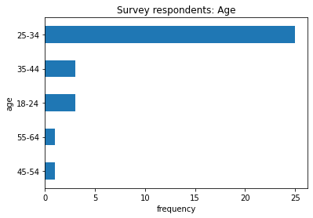

```python
# create a plot of respondents age
ax = df_nominal['age'].value_counts().plot.barh()
ax.invert_yaxis()
ax.set_xlabel('frequency')
ax.set_ylabel('age')
ax.set_title('Survey respondents: Age')

plt.show()
```

The plot above shows the range of ages for those who responded to this survey. From this it is clear that the majority of respondents fall within the age range of 25-34. The ranges for 18-24 and 35-44 are similiar to each other. One encouraging sign is that we have had survey responses for at least all the ranges in our survey which may help prevent a significant bias in survey responses from anay one age range in particular.

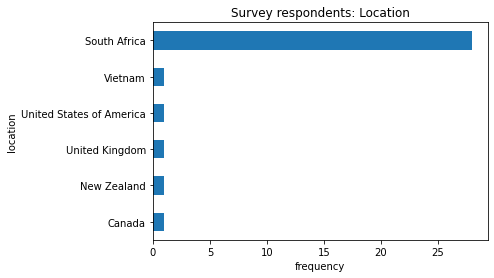

```python
# create a plot of respondents location
ax = df_nominal['location'].value_counts().plot.barh()
ax.invert_yaxis()
ax.set_xlabel('frequency')
ax.set_ylabel('location')
ax.set_title('Survey respondents: Location')

plt.show()
```

The plot above represents the locations where the surveys respondents reside. South Africa has the largest number of respondents which is not surprising given that the majority of my connections on Linkedin are South African. It is encouraging to see the survey received answers from those reside in a few other countries as well. Namely the US, UK, Vietnam, New Zealand and Canada.

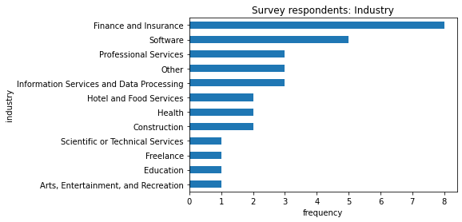

```python
# create a plot of respondents industry
ax = df_nominal['industry'].value_counts().plot.barh()
ax.invert_yaxis()
ax.set_xlabel('frequency')
ax.set_ylabel('industry')
ax.set_title('Survey respondents: Industry')

plt.show()
```

The plot above shows the industries in which the surveys respondents are currently working. One thing that jumps out straight away is that the survey received attention and responses from a wide variety of industries. This is encouraging for the purpose of our analysis as it shows we have a wide range of potential attitudes towards remote working as every industry will have different operational requirements which may affect whether it is possible for them to succesfully allow their employees to work remotely.

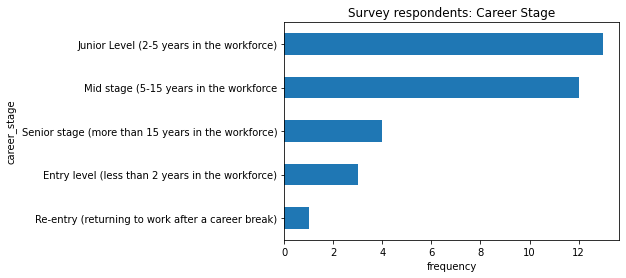

```python
# create a plot of respondents career stage
ax = df_nominal['career_stage'].value_counts().plot.barh()
ax.invert_yaxis()
ax.set_xlabel('frequency')
ax.set_ylabel('career_stage')
ax.set_title('Survey respondents: Career Stage')

plt.show()
```

The plot above gives a visual depcition of the career stages for all respondents of the survey. The two largest groups of respondensts were those at a junior level and those at a mid stage career level. Junior is defined as 2-5 years of working experience while mid stage is defined as 5-15 years of working experience. Once again this is not surprising as the majority of my Linkedin connections would fall into these two career stages.

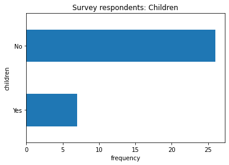

```python
# create a plot of whether or not respondents have children
ax = df_nominal['children'].value_counts().plot.barh()
ax.invert_yaxis()
ax.set_xlabel('frequency')
ax.set_ylabel('children')
ax.set_title('Survey respondents: Children')

plt.show()
```

The plot above shows whether the respondents of this survey have children or not. It appears that the vast majority of respondents do not have children which is unfortunate as it may skew the results of of some survey responses and ideally I would have liked to be able to collect more data for those with children. This is because when designing the survey I thought that those with children may have different priorities and expectations with regard to a working environment when compared to those respondents who do not have children.

#### Univariate Survey Questions

This section deals with the survey responses to questions and perform a univariate data analysis by plotting these results in univariate charts. The chart type I have selected for this purpose is a bar chart as it helps to understand the frequencies that the different categories of questions have occurred.

[figure not shown]

```python
# plot of current work situation
labels = df_nominal['current_wfh'].unique()
labels = [ '\n'.join(wrap(l, 15)) for l in labels ]

ax = df_nominal['current_wfh'].value_counts().plot.bar()
ax.set_ylabel('frequency')
ax.set_xticklabels(labels, rotation=0)
ax.set_title('Are you currently working from home?')

plt.show()
```

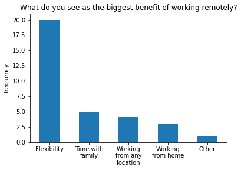

```python
# plot of remote work benefits
labels = df_nominal['pros'].unique()
labels = [ '\n'.join(wrap(l, 11)) for l in labels ]

ax = df_nominal['pros'].value_counts().plot.bar()
ax.set_ylabel('frequency')
ax.set_xticklabels(labels, rotation=0)
ax.set_title('What do you see as the biggest benefit of working remotely?')

plt.show()
```

[figure not shown]

```python
# plot of remote work issues
labels = df_nominal['cons'].unique()
labels = [ '\n'.join(wrap(l, 13)) for l in labels ]

ax = df_nominal['cons'].value_counts().plot.bar()
ax.set_ylabel('frequency')
ax.set_xticklabels(labels, rotation=0)
ax.set_title('What is the biggest issue you see with working remotely?')
#ax.figure.savefig('img/age-bar.png')

plt.show()
```

#### Multivariate analysis

In this section I have compiled a few graphs consisting of mulitvariate data in order to gain an understanding of the interactions between different demographic factors as well as the nominal data obtained from the survey results.

The table below is a crosstab of survey respondents age vs the industry in which they currently work. I have included it because it gives us a good idea of the spread of these two key demographic variables.

```python
# crosstab of age vs industry
pd.crosstab(df_nominal['age'], df_nominal['industry'], margins=True)
```

| industry age | Arts, Entertainment, and Recreation | Construction | Education | Finance and Insurance | Freelance | Health | Hotel and Food Services | Information Services and Data Processing | Other | Professional Services | Scientific or Technical Services | Software | All |
| --- | --- | --- | --- | --- | --- | --- | --- | --- | --- | --- | --- | --- | --- |
| 18-24 | 0 | 0 | 0 | 1 | 0 | 0 | 0 | 0 | 0 | 0 | 0 | 2 | 3 |
| 25-34 | 1 | 2 | 1 | 5 | 1 | 2 | 2 | 1 | 3 | 3 | 1 | 3 | 25 |
| 35-44 | 0 | 0 | 0 | 2 | 0 | 0 | 0 | 1 | 0 | 0 | 0 | 0 | 3 |
| 45-54 | 0 | 0 | 0 | 0 | 0 | 0 | 0 | 1 | 0 | 0 | 0 | 0 | 1 |
| All | 1 | 2 | 1 | 8 | 1 | 2 | 2 | 3 | 3 | 3 | 1 | 5 | 32 |

The graph below plots whether survey respondents have children or not against whether or not they would like to work remotely in the future. I included this because I thought we may see some interesting differences between survey respondents who had kids and those who did not.

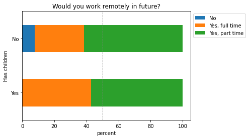

```python
# Generate normalised cross tabulation.
table = pd.crosstab(df_nominal['children'], df_nominal['future_preference'], normalize='index')
# Sort by female responses and convert to percentage.
table = table.sort_values(by='No', ascending=False) * 100

ax = table.plot.barh(stacked=True)
ax.invert_yaxis()
ax.axvline(50, color='grey', linestyle='dashed', linewidth=1)
ax.set_title('Would you work remotely in future?')
ax.set_xlabel('percent')
ax.set_ylabel('Has children')
# Place legent outside plot axes.
ax.legend(bbox_to_anchor=(1.0, 1.0))
plt.show()
```

However the results of the above plot were not as I thought they may be. It seems that for both categories, remote working in some form is prefered while only a few respondents who did not have children indicated that they would not like to work remotely in future. This however may be due to some bias in our sample of survey respopndents with the data skewed much more towards those who do not have children.

### Research Question 1: Are employees working remotely as efficient as they would be if they were working in an office?

```python
# Melt all columns into a single variable.
df_efficiency = df_ordinal.melt(ignore_index=False, value_vars=['I am able to stick to a work schedule.', 'I am expected to respond to emails/messages immediately.', 'I could do my job just as effectively working from home.','My company provides me with the tools and software necessary to make remote working possible.'],var_name='question', value_name='response')
# Set dtypes
df_efficiency['question'] = df_efficiency['question'].astype('category')
rating_levels = ['Strongly disagree', 'Disagree', 'Neither agree nor disagree', 'Agree', 'Strongly agree']
df_efficiency['response'] = df_efficiency['response'].astype(
    pd.CategoricalDtype(categories=rating_levels, ordered=True))
df_efficiency.head()
```

| id | question | response |
| --- | --- | --- |
| 68725236 | I am able to stick to a work schedule. | Agree |
| 68725674 | I am able to stick to a work schedule. | Strongly agree |
| 68725808 | I am able to stick to a work schedule. | Strongly agree |
| 68726565 | I am able to stick to a work schedule. | Agree |
| 68728541 | I am able to stick to a work schedule. | Agree |

```python
# Create a normalised table (sum to 100% across rows).
table_efficiency = pd.crosstab(df_efficiency['question'], df_efficiency['response'],
                    normalize='index') * 100
# Sort by highest value.
table_efficiency.sort_values(by='Strongly agree', inplace=True)
table_efficiency.round(2)
```

| response question | Strongly disagree | Disagree | Neither agree nor disagree | Agree | Strongly agree |
| --- | --- | --- | --- | --- | --- |
| I am expected to respond to emails/messages immediately. | 3.03 | 27.27 | 21.21 | 39.39 | 9.09 |
| I am able to stick to a work schedule. | 0.00 | 6.06 | 0.00 | 45.45 | 48.48 |
| I could do my job just as effectively working from home. | 0.00 | 6.06 | 12.12 | 33.33 | 48.48 |
| My company provides me with the tools and software necessary to make remote working possible. | 0.00 | 9.09 | 3.03 | 30.30 | 57.58 |

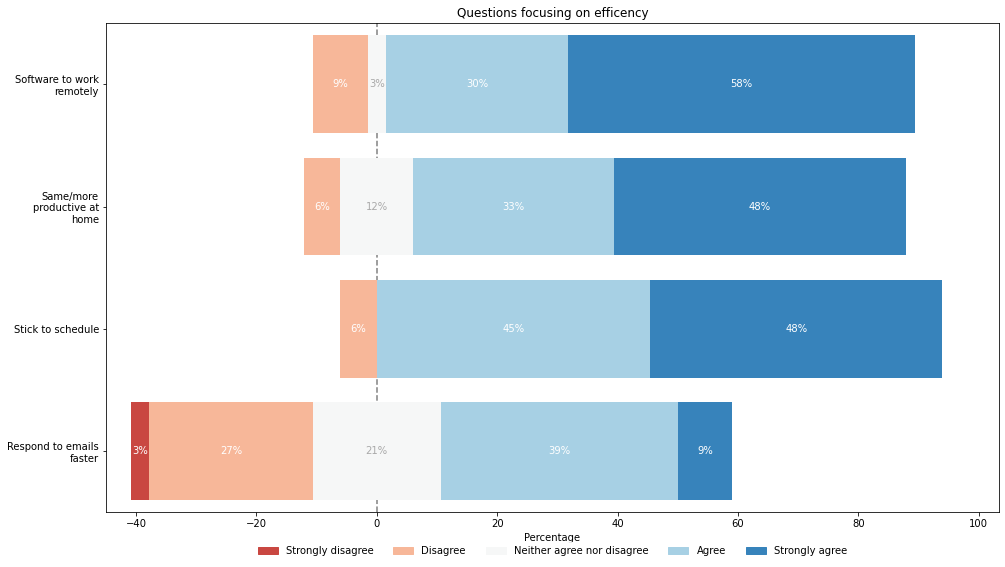

```python
# Better y-axis labels.
motivations = {'I could do my job just as effectively working from home.': 'Same/more productive at home',
               'I am able to stick to a work schedule.': 'Stick to schedule',
               'I am expected to respond to emails/messages immediately.': 'Respond to emails faster',
               'My company provides me with the tools and software necessary to make remote working possible.': 'Software to work remotely'}

# Use textwrap library to break long lines automatically.
motivations = {k: '\n'.join(wrap(v, 17)) for k, v in motivations.items()}

ax = likert_plot.plot_likert_scales(table_efficiency, 'Neither agree nor disagree',
                                    qname_mapping=motivations)
ax.set_title('Questions focusing on efficency')
ax.set_ylim(1, 5)               # Manually correct y-axis.
ax.invert_yaxis()
ax.set_xlabel('Percentage')
plt.show()
```

The plot above uses the likert scale data obtained from the survey questions that map to this specific research question focusing on employee efficiency from remote working. What is interesting to note is that the majority of survey respons agreed with all questions except one that they were able to work as efficiently from home as if they had been in the office. When asked if they were expected to respond to emails faster, the answers were more spread across the board with only 48% of respondents agreeing with this statement. This serves as evidence that for the sample group of survey respondents, they are as efficient working remotely as they would be in an office environment.

### Research Question 2: Are companies able to communicate effectively with their employees?

```python
# Melt all columns into a single variable.
df_communication = df_ordinal.melt(ignore_index=False, value_vars=['My company communicates efficiently.', 'I am able to connect with my manager as well as if I was in the office.', 'I feel that I am able to easily reach my colleagues.', 'I feel that my colleagues keep me in the loop.'],var_name='question', value_name='response')
# Set dtypes.
df_communication['question'] = df_communication['question'].astype('category')
rating_levels = ['Strongly disagree', 'Disagree', 'Neither agree nor disagree', 'Agree', 'Strongly agree']
df_communication['response'] = df_communication['response'].astype(
    pd.CategoricalDtype(categories=rating_levels, ordered=True))
df_communication.head()
```

| id | question | response |
| --- | --- | --- |
| 68725236 | My company communicates efficiently. | Neither agree nor disagree |
| 68725674 | My company communicates efficiently. | Strongly agree |
| 68725808 | My company communicates efficiently. | Strongly agree |
| 68726565 | My company communicates efficiently. | Agree |
| 68728541 | My company communicates efficiently. | Agree |

```python
# Create a normalised table (sum to 100% across rows).
table = pd.crosstab(df_communication['question'], df_communication['response'],
                    normalize='index') * 100
# Sort by highest value.
table.sort_values(by='Strongly agree', inplace=True)
table.round(2)
```

| response question | Strongly disagree | Disagree | Neither agree nor disagree | Agree | Strongly agree |
| --- | --- | --- | --- | --- | --- |
| I am able to connect with my manager as well as if I was in the office. | 0.00 | 30.30 | 18.18 | 42.42 | 9.09 |
| I feel that my colleagues keep me in the loop. | 0.00 | 18.18 | 24.24 | 45.45 | 12.12 |
| I feel that I am able to easily reach my colleagues. | 0.00 | 9.09 | 12.12 | 57.58 | 21.21 |
| My company communicates efficiently. | 3.03 | 9.09 | 6.06 | 54.55 | 27.27 |

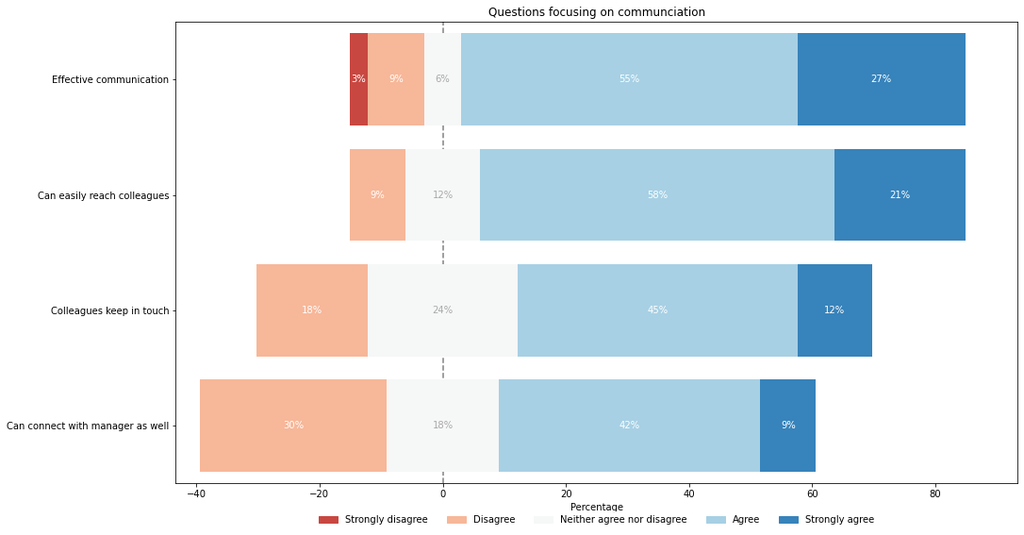

```python
# Better y-axis labels.
labels = {'My company communicates efficiently.':'Effective communication',
          'I am able to connect with my manager as well as if I was in the office.':'Can connect with manager as well',
          'I feel that I am able to easily reach my colleagues.':'Can easily reach colleagues',
          'I feel that my colleagues keep me in the loop.':'Colleagues keep in touch'}

# Use textwrap library to break long lines automatically.
motivations = {k: '\n'.join(wrap(v, 17)) for k, v in motivations.items()}

ax = likert_plot.plot_likert_scales(table, 'Neither agree nor disagree',
                                    qname_mapping=labels)
ax.set_title('Questions focusing on communciation')
ax.set_ylim(1, 5)               # Manually correct y-axis.
ax.invert_yaxis()
ax.set_xlabel('Percentage')
plt.show()
```

The plot above uses the likert scale data obtained from the survey questions that map to this specific research question focusing on how effective the communication between employees and companies for those who are remote working. Once again the results of these questions are very interesting. When asked if respondents thought their company communicated effectively, 82% of respondents agreed. 79% of respondents said that they could easily reach their colleagues and 57% of them felt that their colleagues kept in touch with them. However when asked about their ability to connect with their manager while working remotely only 51% of respondents agreed. This serves as evidience that for the sample group of survey respondents, they find that communication is as effective as if they had been in the working in an office environment.

### Research Question 3: Are employees as happy working from home as they would be in the office?

```python
# Melt all columns into a single variable.
df_happiness = df_ordinal.melt(ignore_index=False, value_vars=['I get the enough support from my manager.', 'I am happy with how frequently I interact with colleagues.', 'I am happy with my work-life balance.', 'I am happy with my ability to work from home.'],var_name='question', value_name='response')
# Set dtypes.
df_happiness['question'] = df_happiness['question'].astype('category')
rating_levels = ['Strongly disagree', 'Disagree', 'Neither agree nor disagree', 'Agree', 'Strongly agree']
df_happiness['response'] = df_happiness['response'].astype(
    pd.CategoricalDtype(categories=rating_levels, ordered=True))
df_happiness.head()
```

| id | question | response |
| --- | --- | --- |
| 68725236 | I get the enough support from my manager. | Agree |
| 68725674 | I get the enough support from my manager. | Strongly agree |
| 68725808 | I get the enough support from my manager. | Strongly agree |
| 68726565 | I get the enough support from my manager. | Strongly agree |
| 68728541 | I get the enough support from my manager. | Agree |

```python
# Create a normalised table (sum to 100% across rows).
table_happiness = pd.crosstab(df_happiness['question'], df_happiness['response'],
                    normalize='index') * 100
# Sort by highest value.
table_happiness.sort_values(by='Strongly agree', inplace=True)
table_happiness.round(2)
```

| response question | Strongly disagree | Disagree | Neither agree nor disagree | Agree | Strongly agree |
| --- | --- | --- | --- | --- | --- |
| I am happy with how frequently I interact with colleagues. | 3.03 | 30.30 | 15.15 | 30.30 | 21.21 |
| I get the enough support from my manager. | 0.00 | 9.09 | 15.15 | 51.52 | 24.24 |
| I am happy with my work-life balance. | 0.00 | 24.24 | 12.12 | 36.36 | 27.27 |
| I am happy with my ability to work from home. | 0.00 | 3.03 | 9.09 | 36.36 | 51.52 |

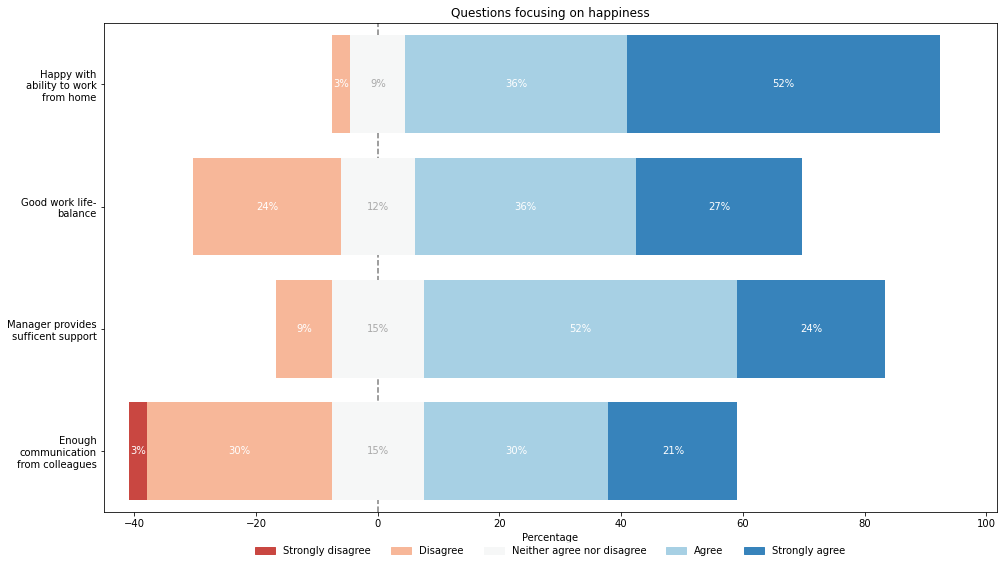

```python
# Better y-axis labels.
labels = {'I get the enough support from my manager.':'Manager provides sufficent support',
          'I am happy with how frequently I interact with colleagues.':'Enough communication from colleagues',
          'I am happy with my work-life balance.':'Good work life-balance',
          'I am happy with my ability to work from home.':'Happy with ability to work from home'}

# Use textwrap library to break long lines automatically.
labels = {k: '\n'.join(wrap(v, 17)) for k, v in labels.items()}

ax = likert_plot.plot_likert_scales(table_happiness, 'Neither agree nor disagree',
                                    qname_mapping=labels)
ax.set_title('Questions focusing on happiness')
ax.set_ylim(1, 5)               # Manually correct y-axis.
ax.invert_yaxis()
ax.set_xlabel('Percentage')
plt.show()
```

The plot above uses the likert scale data obtained from the survey questions that map to this specific research question focusing on how happy survey respondents are when working remotely. A massive 88% of respondents agreed with the statement that they are happy with their ability to work remotely, while 63% of respondents felt that agreed with the statement that they had a good work-life balance. 76% of respondents agreed that their manager provides them with enough support but only 51% of felt that they had enough communication from their colleagues. These results serve as evidence that working remotely does not negatively affect the happiness for the sample group of survey respondents.

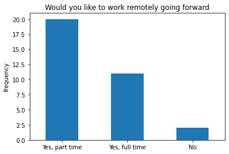

```python
# plot of future remote working preferences
labels = df_nominal['future_preference'].unique()
labels = [ '\n'.join(wrap(l, 15)) for l in labels ]

ax = df_nominal['future_preference'].value_counts().plot.bar()
ax.set_ylabel('frequency')
ax.set_xticklabels(labels, rotation=0)
ax.set_title('Would you like to work remotely going forward')

plt.show()
```

## 4. Conclusion and Discussion

Conducting this survey has been extremely interesting to see how people in different industries and fields of work are having to adapt to the current global crisis. In my own personal life I have seen the huge benefits of being able to work remotely. As indicated by respondents, the biggest benefit to them is the increased flexibilty in their schedule that they derive from working remotely. Extra time with family has also been shown to be a big factor when respondents are faced with a choice of working remotely or based in an office.

In order to improve this study, I would ideally like to sample a much larger group from the sample population. I think that because I only recieved 33 answers to my survey there is a potential that the answers have been skewed/biased due to the specific demographics of the group of respondents. With a larger sample size we may have a demographic that is much more representative of the population and thus our resulyts will be much more accurate and we will be able to draw better conclusions from them.